# Exploratory Data Analysis

```r
library(tidyverse)
library(Hmisc)
```

```r
appstore_df <- read.csv("../Data/AppleStore.csv")
appstore_df %>% arrange(X)
```

| X | id | track_name | size_bytes | currency | price | rating_count_tot | rating_count_ver | user_rating | user_rating_ver | ver | cont_rating | prime_genre | sup_devices.num | ipadSc_urls.num | lang.num | vpp_lic |
| --- | --- | --- | --- | --- | --- | --- | --- | --- | --- | --- | --- | --- | --- | --- | --- | --- |
| 1 | 281656475 | PAC-MAN Premium | 100788224 | USD | 3.99 | 21292 | 26 | 4.0 | 4.5 | 6.3.5 | 4+ | Games | 38 | 5 | 10 | 1 |
| 2 | 281796108 | Evernote - stay organized | 158578688 | USD | 0.00 | 161065 | 26 | 4.0 | 3.5 | 8.2.2 | 4+ | Productivity | 37 | 5 | 23 | 1 |
| 3 | 281940292 | WeatherBug - Local Weather, Radar, Maps, Alerts | 100524032 | USD | 0.00 | 188583 | 2822 | 3.5 | 4.5 | 5.0.0 | 4+ | Weather | 37 | 5 | 3 | 1 |
| 4 | 282614216 | eBay: Best App to Buy, Sell, Save! Online Shopping | 128512000 | USD | 0.00 | 262241 | 649 | 4.0 | 4.5 | 5.10.0 | 12+ | Shopping | 37 | 5 | 9 | 1 |
| 5 | 282935706 | Bible | 92774400 | USD | 0.00 | 985920 | 5320 | 4.5 | 5.0 | 7.5.1 | 4+ | Reference | 37 | 5 | 45 | 1 |
| 6 | 283619399 | Shanghai Mahjong | 10485713 | USD | 0.99 | 8253 | 5516 | 4.0 | 4.0 | 1.8 | 4+ | Games | 47 | 5 | 1 | 1 |
| 7 | 283646709 | PayPal - Send and request money safely | 227795968 | USD | 0.00 | 119487 | 879 | 4.0 | 4.5 | 6.12.0 | 4+ | Finance | 37 | 0 | 19 | 1 |
| 8 | 284035177 | Pandora - Music & Radio | 130242560 | USD | 0.00 | 1126879 | 3594 | 4.0 | 4.5 | 8.4.1 | 12+ | Music | 37 | 4 | 1 | 1 |
| 9 | 284666222 | PCalc - The Best Calculator | 49250304 | USD | 9.99 | 1117 | 4 | 4.5 | 5.0 | 3.6.6 | 4+ | Utilities | 37 | 5 | 1 | 1 |
| 10 | 284736660 | Ms. PAC-MAN | 70023168 | USD | 3.99 | 7885 | 40 | 4.0 | 4.0 | 4.0.4 | 4+ | Games | 38 | 0 | 10 | 1 |

[output cut: 990 more lines]

```r
describe(appstore_df)
```

```
appstore_df

 17  Variables      7197  Observations
-----------------------------------------------------------------------------
X
       n  missing distinct     Info     Mean      Gmd      .05      .10
    7197        0     7197        1     4759     3550    405.8    823.6
     .25      .50      .75      .90      .95
  2090.0   4380.0   7223.0   9424.4  10166.4

lowest :     1     2     3     4     5, highest: 11081 11082 11087 11089 11097
-----------------------------------------------------------------------------
id
        n   missing  distinct      Info      Mean       Gmd       .05
     7197         0      7197         1 863130997 297160703 3.639e+08
      .10       .25       .50       .75       .90       .95
4.227e+08 6.001e+08 9.781e+08 1.082e+09 1.131e+09 1.151e+09

lowest :  281656475  281796108  281940292  282614216  282935706
highest: 1187617475 1187682390 1187779532 1187838770 1188375727
-----------------------------------------------------------------------------
track_name
       n  missing distinct
    7197        0     7195

lowest : _PRISM                                                              -The 穴通し3D- 君の記憶力x反射神経を問う! ～Mr.CURVEからの挑戦状 ～ :) Sudoku +                                                         ! OH Fantastic Free Kick + Kick Wall Challenge                      . Calculator .
highest: 鴨川等間隔の法則                                                    麻雀物語３ 役満乱舞の究極大戦                                       黄金日-贵金属理财投资黄金白银                                       龙之觉醒-热血经典RPG，回味激燃岁月                                  龙珠直播-高清游戏娱乐直播平台
-----------------------------------------------------------------------------
size_bytes
        n   missing  distinct      Info      Mean       Gmd       .05
     7197         0      7107         1 199134454  2.47e+08  12234138
      .10       .25       .50       .75       .90       .95
 20303053  46922752  97153024 181924864 414828134 824317542

lowest :     589824     618496     671744     698800     709632
highest: 3896109056 3956326400 3968637952 3975609344 4025969664
-----------------------------------------------------------------------------
currency
       n  missing distinct    value
    7197        0        1      USD
```

[output cut: 92 more lines]

```
Proportion 0.193 0.022 0.022 0.040 0.099 0.626
-----------------------------------------------------------------------------
lang.num
       n  missing distinct     Info     Mean      Gmd      .05      .10
    7197        0       57    0.856    5.435    6.745        1        1
     .25      .50      .75      .90      .95
       1        1        8       15       21

lowest :  0  1  2  3  4, highest: 63 68 69 74 75
-----------------------------------------------------------------------------
vpp_lic
       n  missing distinct     Info      Sum     Mean      Gmd
    7197        0        2    0.021     7147   0.9931   0.0138

-----------------------------------------------------------------------------
```

```r
appstore_df <- mutate(appstore_df, size_mb = size_bytes/1000000)
appstore_df <- mutate(appstore_df, is_free = price == 0)
appstore_df <- mutate(appstore_df, user_rating_string = as.character(user_rating))
head(appstore_df)
```

|  | X | id | track_name | size_bytes | currency | price | rating_count_tot | rating_count_ver | user_rating | user_rating_ver | ver | cont_rating | prime_genre | sup_devices.num | ipadSc_urls.num | lang.num | vpp_lic | size_mb | is_free | user_rating_string |
| --- | --- | --- | --- | --- | --- | --- | --- | --- | --- | --- | --- | --- | --- | --- | --- | --- | --- | --- | --- | --- |
| 1 | 1 | 281656475 | PAC-MAN Premium | 100788224 | USD | 3.99 | 21292 | 26 | 4.0 | 4.5 | 6.3.5 | 4+ | Games | 38 | 5 | 10 | 1 | 100.78822 | FALSE | 4 |
| 2 | 2 | 281796108 | Evernote - stay organized | 158578688 | USD | 0.00 | 161065 | 26 | 4.0 | 3.5 | 8.2.2 | 4+ | Productivity | 37 | 5 | 23 | 1 | 158.57869 | TRUE | 4 |
| 3 | 3 | 281940292 | WeatherBug - Local Weather, Radar, Maps, Alerts | 100524032 | USD | 0.00 | 188583 | 2822 | 3.5 | 4.5 | 5.0.0 | 4+ | Weather | 37 | 5 | 3 | 1 | 100.52403 | TRUE | 3.5 |
| 4 | 4 | 282614216 | eBay: Best App to Buy, Sell, Save! Online Shopping | 128512000 | USD | 0.00 | 262241 | 649 | 4.0 | 4.5 | 5.10.0 | 12+ | Shopping | 37 | 5 | 9 | 1 | 128.51200 | TRUE | 4 |
| 5 | 5 | 282935706 | Bible | 92774400 | USD | 0.00 | 985920 | 5320 | 4.5 | 5.0 | 7.5.1 | 4+ | Reference | 37 | 5 | 45 | 1 | 92.77440 | TRUE | 4.5 |
| 6 | 6 | 283619399 | Shanghai Mahjong | 10485713 | USD | 0.99 | 8253 | 5516 | 4.0 | 4.0 | 1.8 | 4+ | Games | 47 | 5 | 1 | 1 | 10.48571 | FALSE | 4 |

We will first add certain variables to the data set that are more relevant (like total size of an app in megabytes and if the app is free/paid).

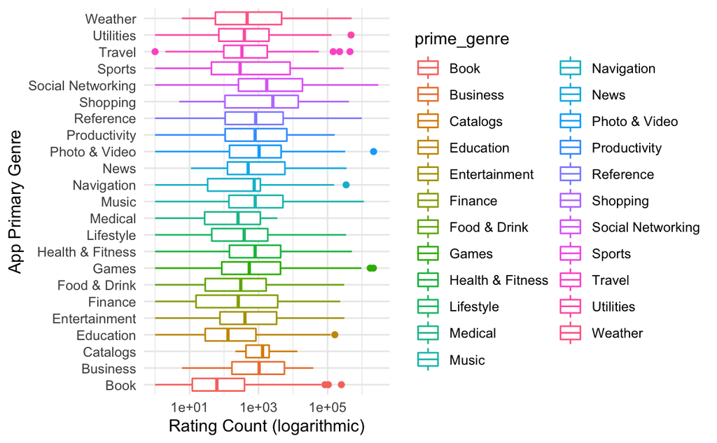

```r
appstore_df %>% ggplot() + geom_boxplot(mapping = aes(x=prime_genre, y = rating_count_tot, color=prime_genre)) + scale_y_log10() + coord_flip() + labs(y="Rating Count (logarithmic)") + labs(x="App Primary Genre") + theme_minimal()
```

Since a total downlaod count is not available in this dataset due to restrictions from Apple, we will treat the total rating count of an app to be a rough estimate of its total downloads. A higher rating count implies that the app is more successful. We can see how the popularity of every app genre with the graph above. The app genre plays a minor impact in the success of an app (exception is the Book genre).

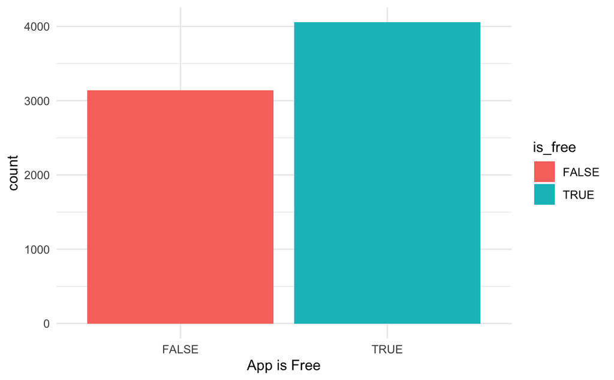

```r
appstore_df %>% ggplot() + geom_bar(mapping=aes(x=is_free, fill=is_free)) + labs(x="App is Free") + theme_minimal()
```

We can see that there are more free apps in the Apple App Store than paid apps, which can range from $0.99 to $299.99.

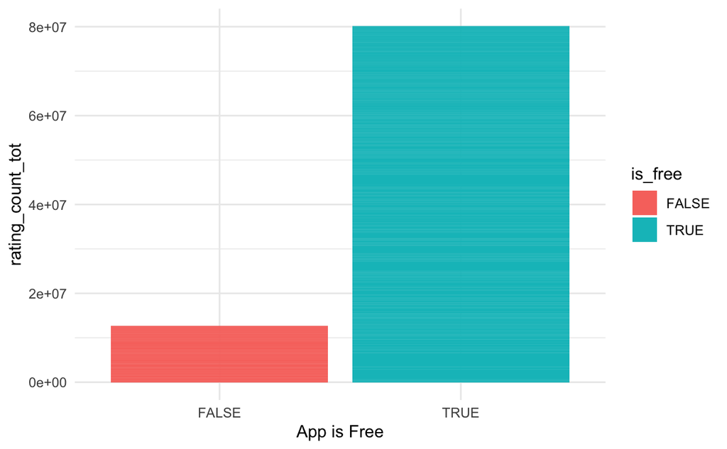

```r
appstore_df %>% ggplot() + geom_col(mapping=aes(x=is_free, y=rating_count_tot, fill=is_free)) + labs(x="App is Free") + theme_minimal()
```

The total rating count, which implies the total download count, of free apps are much higher than paid apps. This ratio is significantly higher than the number of free apps to paid apps, which implies that free apps are typically more successful in the App Store.

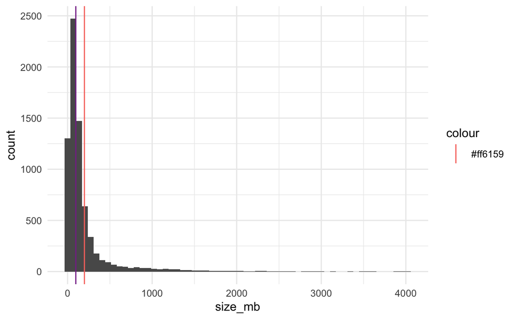

```r
appstore_df %>% ggplot() + geom_histogram(mapping = aes(x=size_mb), bins = 60) + geom_vline(mapping= aes(xintercept= median(appstore_df$size_mb)), color="#873096") + geom_vline(mapping= aes(xintercept= mean(appstore_df$size_mb), color="#ff6159")) + theme_minimal()
```

We can see the distribution of the app sizes throughout the ~7000 apps in the data set. The red line represents the mean of the app sizes in megabytes, while the purple line represents the median of the app sizes in megabytes. We can see that most apps are under the 500 MB threshold.

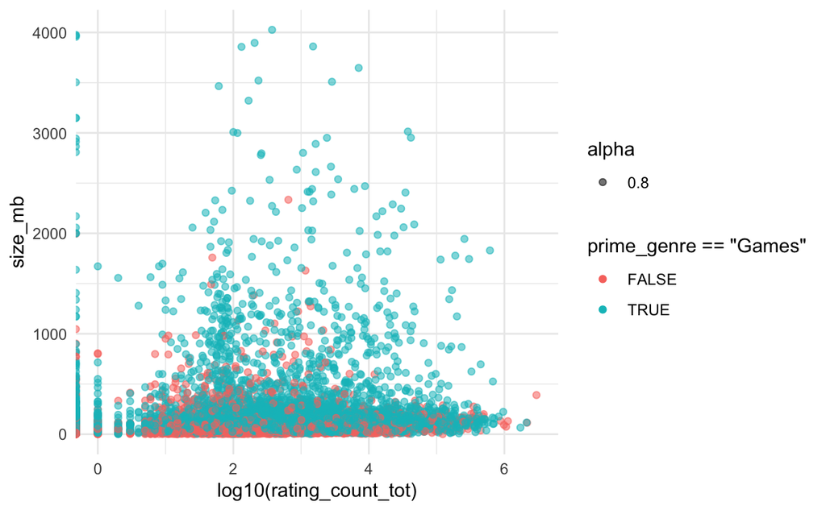

```r
appstore_df %>% ggplot() + geom_point(mapping = aes(y=size_mb, x=log10(rating_count_tot), color=prime_genre == "Games", alpha=0.8)) + theme_minimal()
```

This scatterplot outlines many aspects about the data that we’re investigating. The most striking aspect is that most of the apps in the dataset fall into the Games category, as you can see with the blue coloring. Also, most of the apps with greater than 1 GB download size are in fact games. Every other app category mostly falls under the 1 GB download size. In addition, the super-popular apps to the far right of the graph typically do not exceed the 2 GB threshold.

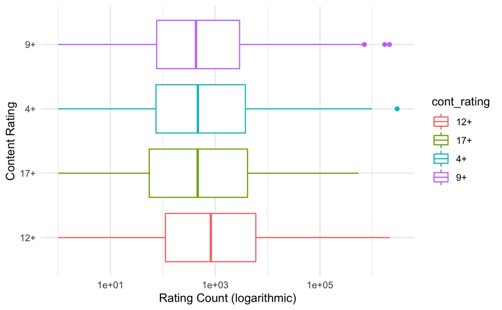

```r
appstore_df %>% ggplot() + geom_boxplot(mapping = aes(x=cont_rating, y = rating_count_tot, color=cont_rating)) + scale_y_log10() + coord_flip() + labs(y="Rating Count (logarithmic)") + labs(x="Content Rating") + theme_minimal()
```

We could see that content rating plays a very minor roll in determining the success of an app.

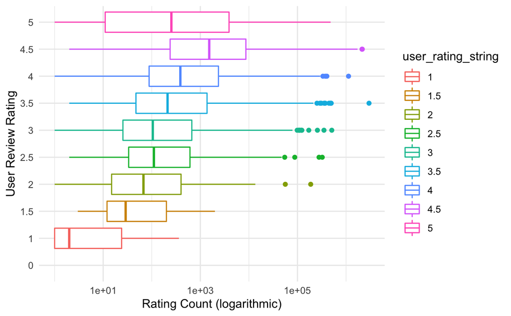

```r
appstore_df %>% ggplot() + geom_boxplot(mapping = aes(x=user_rating_string, y = rating_count_tot, color=user_rating_string)) + scale_y_log10() + coord_flip() + labs(y="Rating Count (logarithmic)") + labs(x="User Review Rating") + theme_minimal()
```

## Summary

- Content rating does not affect an app’s success.
- If the user rating is below 1.5, an app’s success is harmed.
- Most incredibly popular apps have a total size below 2 gigabytes or 2000 megabytes.
- Most apps that are over 1 GB are usually games.
- Free apps have significantly more downloads than paid apps.